# Домашнее задание 2

May 27, 2018

Во второй домашке узнаем всё про пассажиров Титаника и закрепим изученное на семинаре :)

Прежде всего — библиотеки!

- **Упражнение 0.**

Отключите в этом куске кода сообщения и предупреждения.

```r
library(tidyverse) # обработка данных, графики...
library(vcd) # мозаичные графики для качественных переменных
library(skimr) # описательные статистики
library(rio) # импорт фантастического количества форматов данных
library(ggalluvial) # потоковые диаграммы для качественных переменных
library(titanic) # набор данных о пассажирах Титаника
library(corrplot) # визуализация корреляций
library(reshape2) # длинные и широкие таблицы
```

Описание данных:

- Survived - выжил ли пассажир (1 — да, 0 — нет)
- Pclass - класс билета (1 — первый, 2 — второй, 3 — третий)
- Name - имя пассажира
- Sex - пол пассажира
- Age - возраст пассажира
- SibSp - число братьев или сестер / присутствие мужа или жены на корабле
- Parch - количество детей / родителей на корабле
- Ticket - номер билета
- Fare - стоимость билета
- Cabin - номер каюты
- Embarked - порт посадки (C = Cherbourg, Q = Queenstown, S = Southampton)

Прежде всего положим данные в переменную `df` и посмотрим описателные статистики.

```r
df <- import('titanic.csv')
skim(df)
```

```
## Skim summary statistics
##  n obs: 891
##  n variables: 12
```

```
##
## Variable type: character
##  variable missing complete   n min max empty n_unique
##     Cabin       0      891 891   0  15   687      148
##  Embarked       0      891 891   0   1     2        4
##      Name       0      891 891  12  82     0      891
##       Sex       0      891 891   4   6     0        2
##    Ticket       0      891 891   3  18     0      681
##
## Variable type: integer
##     variable missing complete   n   mean     sd p0   p25 p50   p75 p100
##        Parch       0      891 891   0.38   0.81  0   0     0   0      6
##  PassengerId       0      891 891 446    257.35  1 223.5 446 668.5  891
##       Pclass       0      891 891   2.31   0.84  1   2     3   3      3
##        SibSp       0      891 891   0.52   1.1   0   0     0   1      8
##     Survived       0      891 891   0.38   0.49  0   0     0   1      1
##      hist
##  ▇▂▁▁▁▁▁▁
##  ▇▇▇▇▇▇▇▇
##  ▃▁▁▃▁▁▁▇
##  ▇▁▁▁▁▁▁▁
##  ▇▁▁▁▁▁▁▅
##
## Variable type: numeric
##  variable missing complete   n mean    sd   p0   p25   p50 p75   p100
##       Age     177      714 891 29.7 14.53 0.42 20.12 28     38  80
##      Fare       0      891 891 32.2 49.69 0     7.91 14.45  31 512.33
##      hist
##  ▂▃▇▆▃▂▁▁
##  ▇▁▁▁▁▁▁▁
```

- Сколько наблюдений в данных?
- Сколько переменных?
- Все ли переменные соответсвуют своему типу по смыслу?
- **Упражнение 1.**

Пассажиры Титаника могли попасть на корабаль из трёх портов, два из которых находились в Великобритании, а один во Франции.

```r
table(df$Embarked)
```

```
##
##       C   Q   S
##   2 168  77 644
```

```r
df2 <- mutate(df, Embarked = fct_collapse(Embarked, GB = c('Q', 'C')))
table(df2$Embarked)
```

```
##
##      GB   S
##   2 245 644
```

- **Упражнение 2.**

Выясним, как связаны класс каюты пассажира и выживание.

- Составьте таблицу сопряжённости признаков `PClass` и `Survived`.
- Проведите тест на независимость этих признаков.
- Какой вывод можно сделать?

```r
ctable <- table(df$Pclass, df$Survived)
chisq.test(ctable)
```

```
##
##  Pearson's Chi-squared test
##
## data:  ctable
## X-squared = 102.89, df = 2, p-value < 2.2e-16
```

- **Упражнение 3.**

Посмотрим, как соотносятся пол пассажира и класс каюты с его выживанием.

- Составьте таблицу сопряжённости для признаков `Pclass`, `Survived`, `Sex` и сохраните её. Не забудьте добавить названия! За это отвечает аргумент `dnn` :)
- Постройте мозаичный график для получившейся таблицы, обязателно цветной и с легендой!
- Что на нём изображено?

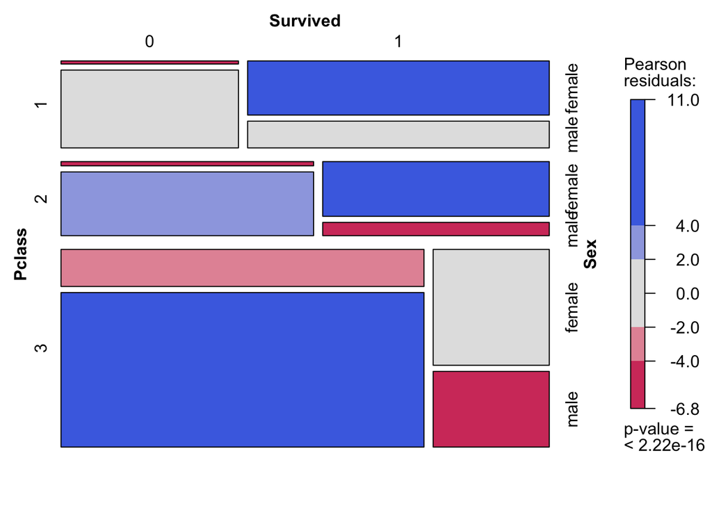

```r
ctable <- table(df$Pclass, df$Survived, df$Sex, dnn = c('Pclass', 'Survived', 'Sex'))
mosaic(ctable, shade = TRUE, legend = TRUE)
```

- **Упражнение 4.**

Продолжим исследовать информацию о пассажирах!

- Посчитайте корреляции признаков `Survived`, `Age`, `SibSp`, `Parch`, `Fare`.
- Какой признак сильнее всего коррелирует с выживанием?
- Визуализируйте корреляции: постройте график со значениями выше диагонали и квадратами внутри.
- Для чего понадобился аргумент `use = 'pairwise.complete.obs'`?

```r
mcor <- cor(df[, c('Survived', 'Age', 'SibSp', 'Parch', 'Fare')], use = 'pairwise.complete.obs')
mcor
```

```
##             Survived         Age      SibSp       Parch       Fare
## Survived  1.00000000 -0.07722109 -0.0353225  0.08162941 0.25730652
## Age      -0.07722109  1.00000000 -0.3082468 -0.18911926 0.09606669
## SibSp    -0.03532250 -0.30824676  1.0000000  0.41483770 0.15965104
## Parch     0.08162941 -0.18911926  0.4148377  1.00000000 0.21622494
## Fare      0.25730652  0.09606669  0.1596510  0.21622494 1.00000000
```

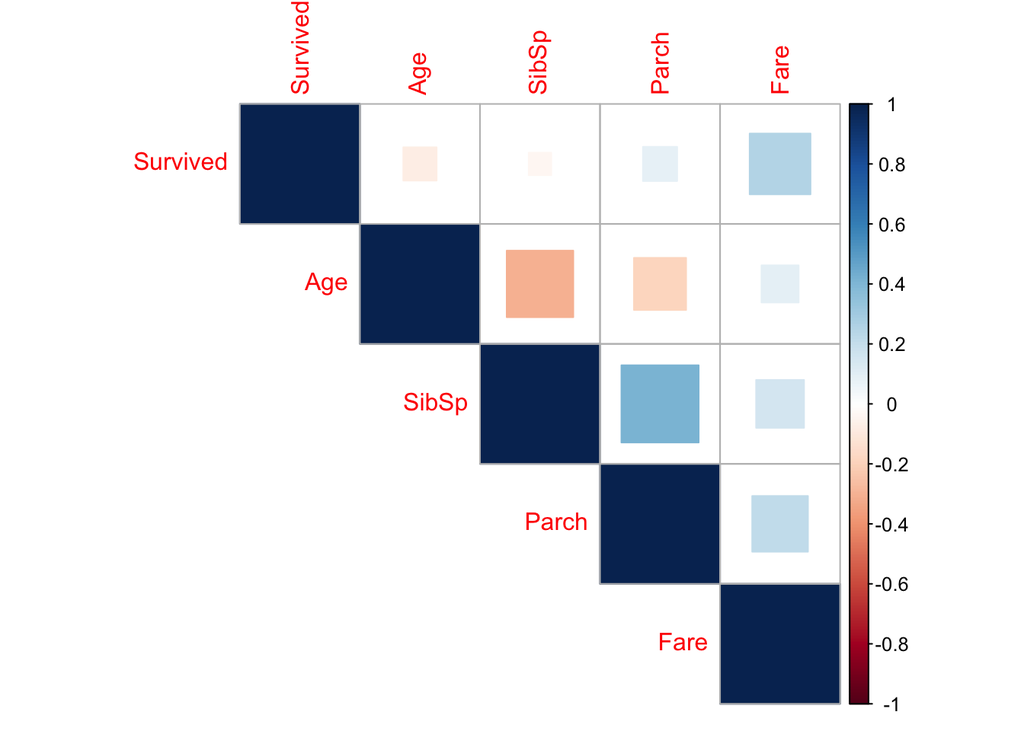

```r
corrplot(mcor, method = 'square', type = 'upper')
```

- **Упражнение 5.**

Посмотрим на распределение возраста пассажиров Титаника.

- Постройте скрипичный график командой `geom_viloin()` из пакета `ggplot2`. Не забудьте подписать оси и придумать название!
- Разбейте график на две панели по признаку `Survived`.

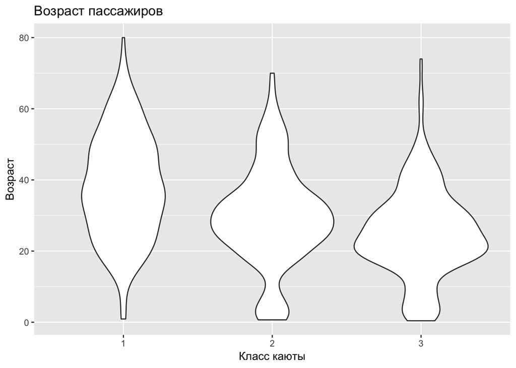

```r
df <- mutate(df, Pclass = factor(Pclass))

ggplot(data = df, aes(x = Pclass, y = Age)) +
  geom_violin() +
  labs(x = 'Класс каюты', y = 'Возраст', title = 'Возраст пассажиров')
```

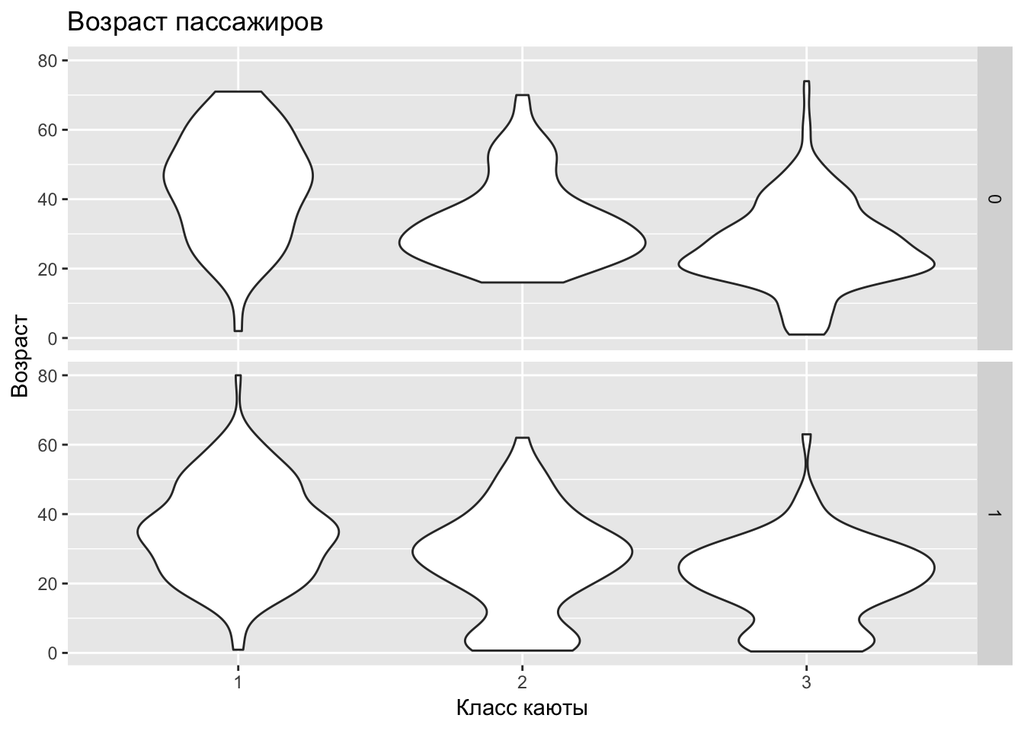

```r
ggplot(data = df, aes(x = factor(Pclass), y = Age)) +
  geom_violin() +
  facet_grid(Survived ~ .) +
  labs(x = 'Класс каюты', y = 'Возраст', title = 'Возраст пассажиров')
```

- **Упражнение 6.**

Цель задания — построить потоковую диаграмму!

- Посчитайте таблицу частот по переменным `Pclass`, `Sex`, `Survived`. Для этого сгруппируйте наблюдения по этим переменным, а затем для каждой группы посчитайте количество наблюдений `n()`.
- Дополните код для потоковой диаграммы. В качестве аргумента `data` нужно указать созданную таблицу частот, в аргументы `axis_` передайте класс каюты, пол и выживыших в этом порядке. Аргумент `fill` отвечает за цвет потоков — раскрасьте их по классу каюты.

```r
freq_table <- group_by(df, Pclass, Sex, Survived) %>% summarise(freq = n())
freq_table
```

```
## # A tibble: 12 x 4
## # Groups:   Pclass, Sex [?]
##    Pclass Sex    Survived  freq
##    <fct>  <chr>     <int> <int>
##  1 1      female        0     3
##  2 1      female        1    91
##  3 1      male          0    77
##  4 1      male          1    45
##  5 2      female        0     6
##  6 2      female        1    70
##  7 2      male          0    91
##  8 2      male          1    17
##  9 3      female        0    72
## 10 3      female        1    72
## 11 3      male          0   300
## 12 3      male          1    47
```

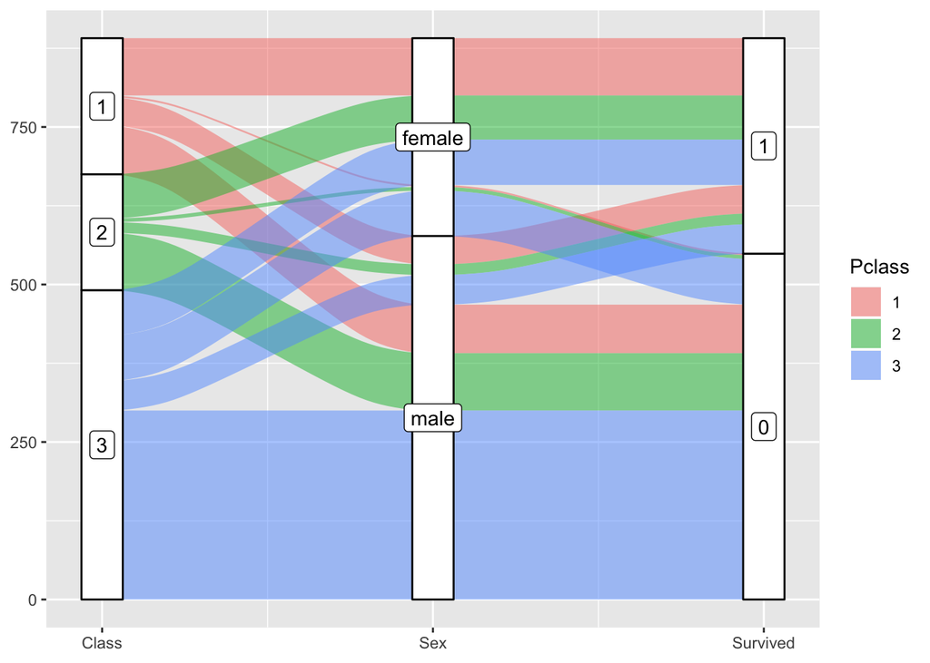

```r
ggplot(data = freq_table, aes(weight = freq, axis1 = Pclass, axis2 = Sex, axis3 = Survived)) +
  geom_alluvium(aes(fill = Pclass), width = 1/12) +
  geom_stratum(width = 1/8) +
  geom_label(stat = 'stratum', label.strata = TRUE) +
  scale_x_continuous(breaks = 1:3, labels = c('Class', 'Sex', 'Survived'))
```

- **Упражнение 7.**

```r
dcast(df, SibSp ~ Pclass, value.var = 'Fare', fun.aggregate = mean)
```

```
##   SibSp         1        2         3
## 1     0  75.22336 15.53233  9.832689
## 2     1  88.49202 28.38568 16.658487
## 3     2 159.97584 44.46875 19.564993
## 4     3 263.00000 21.00000 24.378483
## 5     4       NaN      NaN 31.855556
## 6     5       NaN      NaN 46.900000
## 7     8       NaN      NaN 69.550000
```

- **Упражнение 8.**

В вашем распоряжении новые (но недостоверные) данные о пассажирах Титаника.

- Загрузите их из файла `titanic_info.xlsx`.
- Сколько наблюдений в новых данных? Какие переменные совпадают с основными данными?
- Объедините новую таблицу с таблицей `df` всеми возможными способами.
- Для каждого случая определите колчиство наблюдений в получившейся таблице.

```r
new_df <- import('titanic_info.xlsx')
lj <- left_join(df, new_df, by = 'PassengerId')
skim(lj)
```

```
## Skim summary statistics
##  n obs: 891
##  n variables: 14
##
## Variable type: character
##  variable missing complete   n min max empty n_unique
##     Cabin       0      891 891   0  15   687      148
##  Embarked       0      891 891   0   1     2        4
##      Name       0      891 891  12  82     0      891
##       Sex       0      891 891   4   6     0        2
##    Ticket       0      891 891   3  18     0      681
##
## Variable type: factor
##  variable missing complete   n n_unique                    top_counts
##    Pclass       0      891 891        3 3: 491, 1: 216, 2: 184, NA: 0
##  ordered
##    FALSE
##
## Variable type: integer
##  variable missing complete   n mean   sd p0 p25 p50 p75 p100     hist
##     Parch       0      891 891 0.38 0.81  0   0   0   0    6 ▇▂▁▁▁▁▁▁
##     SibSp       0      891 891 0.52 1.1   0   0   0   1    8 ▇▁▁▁▁▁▁▁
##  Survived       0      891 891 0.38 0.49  0   0   0   1    1 ▇▁▁▁▁▁▁▅
##
## Variable type: numeric
##     variable missing complete   n   mean     sd   p0    p25    p50   p75
##          Age     177      714 891  29.7   14.53 0.42  20.12  28     38
##         Fare       0      891 891  32.2   49.69 0      7.91  14.45  31
##     Holidays      94      797 891 187.19 106.08 0     96    193    275
##  PassengerId       0      891 891 446    257.35 1    223.5  446    668.5
##         Pets      91      800 891   2.53   1.72 0      1      2      4
##    p100     hist
##   80    ▂▃▇▆▃▂▁▁
##  512.33 ▇▁▁▁▁▁▁▁
##  365    ▇▇▇▇▇▇▇▇
##  891    ▇▇▇▇▇▇▇▇
##    5    ▇▇▁▇▆▁▇▇
```

```r
rj <- right_join(df, new_df, by = 'PassengerId')
skim(rj)
```

```
## Skim summary statistics
##  n obs: 836
##  n variables: 14
##
## Variable type: character
##  variable missing complete   n min max empty n_unique
##     Cabin       0      836 836   0  15   645      140
##  Embarked       0      836 836   0   1     2        4
##      Name       0      836 836  12  82     0      836
##       Sex       0      836 836   4   6     0        2
##    Ticket       0      836 836   3  18     0      652
##
## Variable type: factor
##  variable missing complete   n n_unique                    top_counts
##    Pclass       0      836 836        3 3: 463, 1: 202, 2: 171, NA: 0
##  ordered
##    FALSE
##
## Variable type: integer
##  variable missing complete   n mean   sd p0 p25 p50 p75 p100     hist
##     Parch       0      836 836 0.37 0.8   0   0   0   0    6 ▇▁▁▁▁▁▁▁
##     SibSp       0      836 836 0.51 1.09  0   0   0   1    8 ▇▁▁▁▁▁▁▁
##  Survived       0      836 836 0.39 0.49  0   0   0   1    1 ▇▁▁▁▁▁▁▅
##
## Variable type: numeric
##     variable missing complete   n   mean     sd   p0    p25    p50    p75
##          Age     170      666 836  29.88  14.51 0.42  21     28.5   38.75
##         Fare       0      836 836  31.83  48.18 0      7.9   13.82  30.5
##     Holidays      39      797 836 187.19 106.08 0     96    193    275
##  PassengerId       0      836 836 443.75 261.79 1    217.75 440.5  673.25
##         Pets      36      800 836   2.53   1.72 0      1      2      4
##    p100     hist
##   80    ▂▃▇▆▃▂▁▁
##  512.33 ▇▁▁▁▁▁▁▁
##  365    ▇▇▇▇▇▇▇▇
##  891    ▇▇▇▇▇▇▇▇
##    5    ▇▇▁▇▆▁▇▇
```

```r
ij <- inner_join(df, new_df, by = 'PassengerId')
skim(ij)
```

```
## Skim summary statistics
##  n obs: 836
##  n variables: 14
##
## Variable type: character
##  variable missing complete   n min max empty n_unique
##     Cabin       0      836 836   0  15   645      140
##  Embarked       0      836 836   0   1     2        4
##      Name       0      836 836  12  82     0      836
##       Sex       0      836 836   4   6     0        2
##    Ticket       0      836 836   3  18     0      652
##
## Variable type: factor
##  variable missing complete   n n_unique                    top_counts
##    Pclass       0      836 836        3 3: 463, 1: 202, 2: 171, NA: 0
##  ordered
##    FALSE
##
## Variable type: integer
##  variable missing complete   n mean   sd p0 p25 p50 p75 p100     hist
##     Parch       0      836 836 0.37 0.8   0   0   0   0    6 ▇▁▁▁▁▁▁▁
##     SibSp       0      836 836 0.51 1.09  0   0   0   1    8 ▇▁▁▁▁▁▁▁
##  Survived       0      836 836 0.39 0.49  0   0   0   1    1 ▇▁▁▁▁▁▁▅
##
## Variable type: numeric
##     variable missing complete   n   mean     sd   p0    p25    p50    p75
##          Age     170      666 836  29.88  14.51 0.42  21     28.5   38.75
##         Fare       0      836 836  31.83  48.18 0      7.9   13.82  30.5
##     Holidays      39      797 836 187.19 106.08 0     96    193    275
##  PassengerId       0      836 836 443.75 261.79 1    217.75 440.5  673.25
##         Pets      36      800 836   2.53   1.72 0      1      2      4
##    p100     hist
##   80    ▂▃▇▆▃▂▁▁
##  512.33 ▇▁▁▁▁▁▁▁
##  365    ▇▇▇▇▇▇▇▇
##  891    ▇▇▇▇▇▇▇▇
##    5    ▇▇▁▇▆▁▇▇
```

```r
fj <- full_join(df, new_df, by = 'PassengerId')
skim(fj)
```

```
## Skim summary statistics
##  n obs: 891
##  n variables: 14
##
## Variable type: character
##  variable missing complete   n min max empty n_unique
##     Cabin       0      891 891   0  15   687      148
##  Embarked       0      891 891   0   1     2        4
##      Name       0      891 891  12  82     0      891
##       Sex       0      891 891   4   6     0        2
##    Ticket       0      891 891   3  18     0      681
##
## Variable type: factor
##  variable missing complete   n n_unique                    top_counts
##    Pclass       0      891 891        3 3: 491, 1: 216, 2: 184, NA: 0
##  ordered
##    FALSE
##
## Variable type: integer
##  variable missing complete   n mean   sd p0 p25 p50 p75 p100     hist
##     Parch       0      891 891 0.38 0.81  0   0   0   0    6 ▇▂▁▁▁▁▁▁
##     SibSp       0      891 891 0.52 1.1   0   0   0   1    8 ▇▁▁▁▁▁▁▁
##  Survived       0      891 891 0.38 0.49  0   0   0   1    1 ▇▁▁▁▁▁▁▅
##
## Variable type: numeric
##     variable missing complete   n   mean     sd   p0    p25    p50   p75
##          Age     177      714 891  29.7   14.53 0.42  20.12  28     38
##         Fare       0      891 891  32.2   49.69 0      7.91  14.45  31
##     Holidays      94      797 891 187.19 106.08 0     96    193    275
##  PassengerId       0      891 891 446    257.35 1    223.5  446    668.5
##         Pets      91      800 891   2.53   1.72 0      1      2      4
##    p100     hist
##   80    ▂▃▇▆▃▂▁▁
##  512.33 ▇▁▁▁▁▁▁▁
##  365    ▇▇▇▇▇▇▇▇
##  891    ▇▇▇▇▇▇▇▇
##    5    ▇▇▁▇▆▁▇▇
```

Бонус победителю!

Если все упражнения получились, можно смело нажимать `Knit` :)